# Прогнозирование температуры стали

### Объёмы подачи сыпучих материалов

**Исследуем столбцы с объемами сыпучих материалов: `сыпуч_мат_...`**

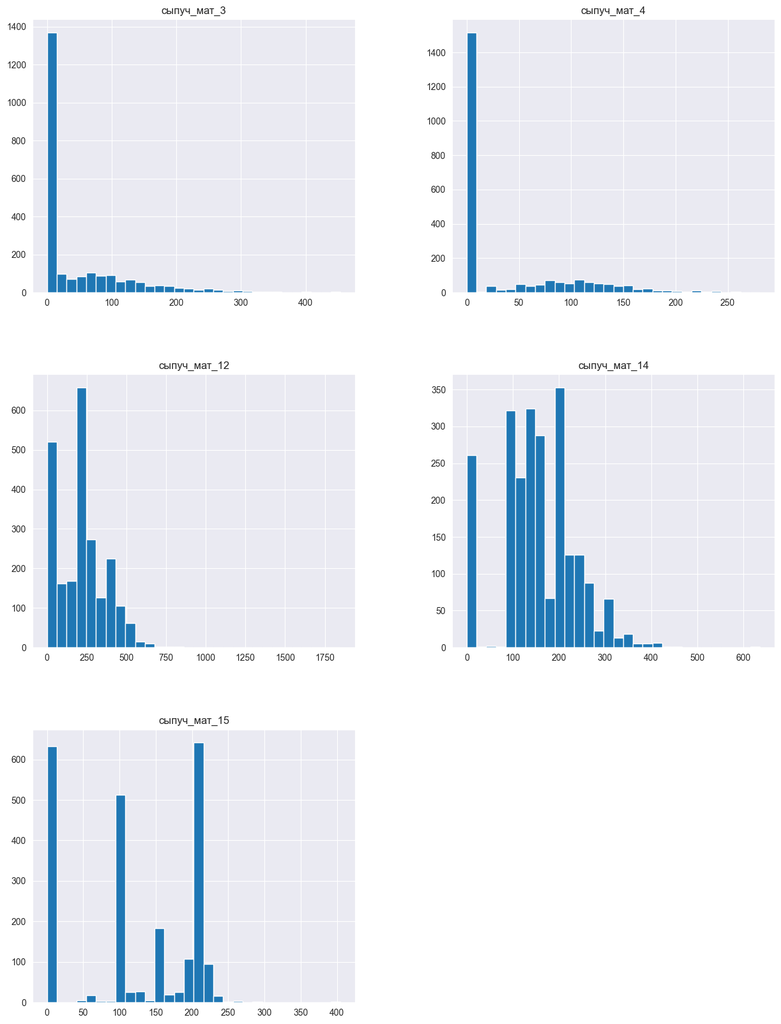

```python
# строим гистограммы
filter_col = [col for col in df_merged if col.startswith('сыпуч_мат')]
df_merged[filter_col].hist(figsize=(15, 20), bins=30)
plt.show()
```

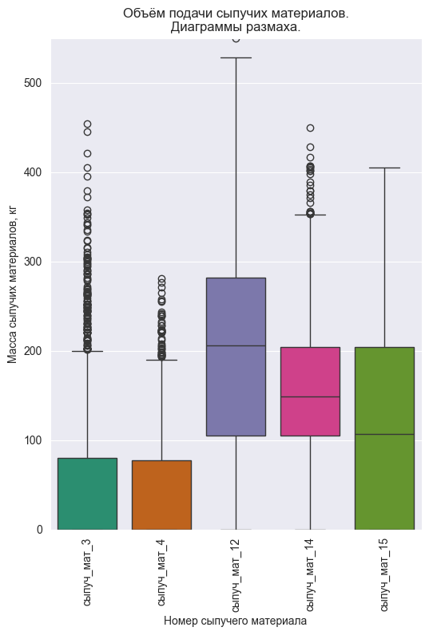

```python
# построим диаграммы размаха
ax = plt.subplots(figsize = (6,8))
ax = sns.boxplot(x="variable", y="value",
                 data=pd.melt(df_merged[filter_col]), palette=palette)
ax.set_title('Объём подачи сыпучих материалов.\nДиаграммы размаха.')
ax.set_ylabel('Масса сыпучих материалов, кг')
ax.set_xlabel('Номер сыпучего материала')
ax.set_xticklabels(ax.get_xticklabels(),rotation=90)
sns.set_style('darkgrid')

plt.ylim(0, 550)
plt.show()
```

```python
# выведем основные описательные статистики
df_merged.describe()
```

|  | длит_нагрева | полная_мощность | работа | сыпуч_мат_3 | сыпуч_мат_4 | сыпуч_мат_12 | сыпуч_мат_14 | сыпуч_мат_15 | газ_1 | первая_темп | последняя_темп | проволока_1 | проволока_2 |
| --- | --- | --- | --- | --- | --- | --- | --- | --- | --- | --- | --- | --- | --- |
| count | 2329.000000 | 2329.000000 | 2329.000000 | 2329.000000 | 2329.000000 | 2329.000000 | 2329.000000 | 2329.000000 | 2329.000000 | 2329.000000 | 2329.000000 | 2329.000000 | 2329.000000 |
| mean | 807.600687 | 5.425555 | 935.346198 | 47.348218 | 37.303564 | 208.415629 | 153.853585 | 119.952769 | 11.375600 | 1587.386003 | 1593.365393 | 102.443601 | 17.609859 |
| std | 340.897332 | 2.121037 | 446.293807 | 75.310430 | 58.643238 | 157.062272 | 81.404354 | 84.640443 | 6.392041 | 23.619841 | 11.200915 | 43.539993 | 33.624771 |
| min | 57.000000 | 0.463904 | 46.967133 | 0.000000 | 0.000000 | 0.000000 | 0.000000 | 0.000000 | 0.008399 | 1519.000000 | 1541.000000 | 0.000000 | 0.000000 |
| 25% | 581.000000 | 3.968624 | 637.080260 | 0.000000 | 0.000000 | 105.000000 | 105.000000 | 0.000000 | 7.282948 | 1571.000000 | 1587.000000 | 73.207679 | 0.000000 |
| 50% | 778.000000 | 5.259210 | 879.245492 | 0.000000 | 0.000000 | 206.000000 | 149.000000 | 107.000000 | 10.100950 | 1587.000000 | 1593.000000 | 101.119201 | 0.000000 |
| 75% | 993.000000 | 6.664035 | 1172.887154 | 80.000000 | 77.000000 | 282.000000 | 204.000000 | 204.000000 | 14.216688 | 1603.000000 | 1598.000000 | 128.091599 | 23.102560 |
| max | 4189.000000 | 21.324685 | 6330.135700 | 454.000000 | 281.000000 | 1849.000000 | 636.000000 | 405.000000 | 77.995040 | 1660.000000 | 1653.000000 | 330.314424 | 282.780152 |

**Итог:**

- Гистограммы и диаграммы размаха подачи сыпучих материалов выглядят неестественно, поскольку некоторые материалы подавались редко и большинство данных представлено нулями.
- В сыпучем материале №12 обнаружены существенные выбросы, максимальное значение: 1849 кг. при медиане 206 кг.

### Объёмы подачи газа для продувки сплавов

**Исследуем столбец с продувкой газом: `газ_1`.**

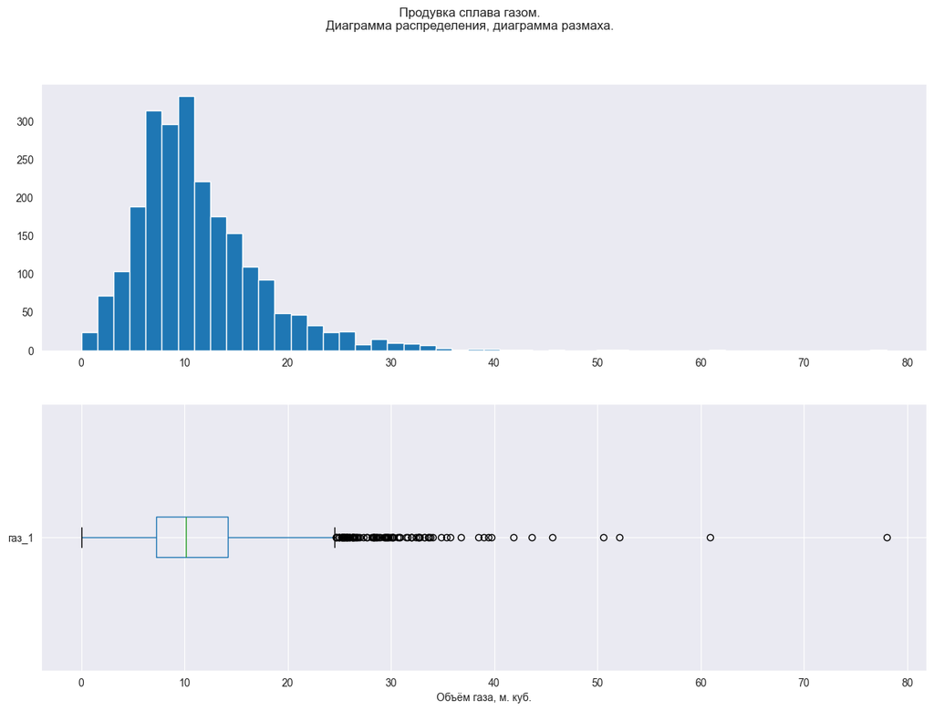

```
count    2329.000000
mean       11.375600
std         6.392041
min         0.008399
25%         7.282948
50%        10.100950
75%        14.216688
max        77.995040
Name: газ_1, dtype: float64
```

```python
# исследуем длительности нагрева
plot_hist_boxplot(df=df_merged,
                  column='газ_1',
                  title='Продувка сплава газом.\n\
Диаграмма распределения, диаграмма размаха.',
                  xlabel='Объём газа, м. куб.',
                  bins=[50])
```

**Итог:**

- Распределение объёмов газа не выглядит нормальным.
- Имеются выбросы вверх до ~78 м. куб., что выглядит естественно, но для улучшения прогнозной модели наиболее мощные выбросы удалим.

### Первая и последняя температура сплава

**Исследуем столбцы с первой и последней температурой сплавов: `первая_темп`, `последняя_темп`.**

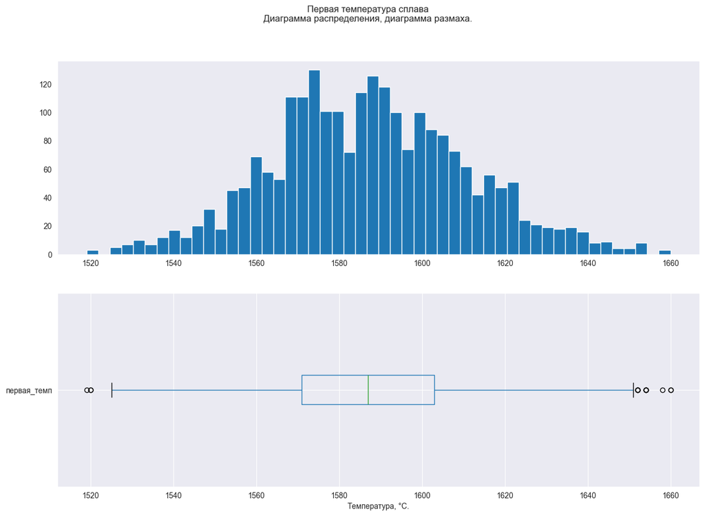

```
count    2329.000000
mean     1587.386003
std        23.619841
min      1519.000000
25%      1571.000000
50%      1587.000000
75%      1603.000000
max      1660.000000
Name: первая_темп, dtype: float64
```

```python
# исследуем первую температуру сплавов
plot_hist_boxplot(df=df_merged,
                  column='первая_темп',
                  title='Первая температура сплава\n\
Диаграмма распределения, диаграмма размаха.',
                  xlabel='Температура, °C.',
                  bins=[50])
```

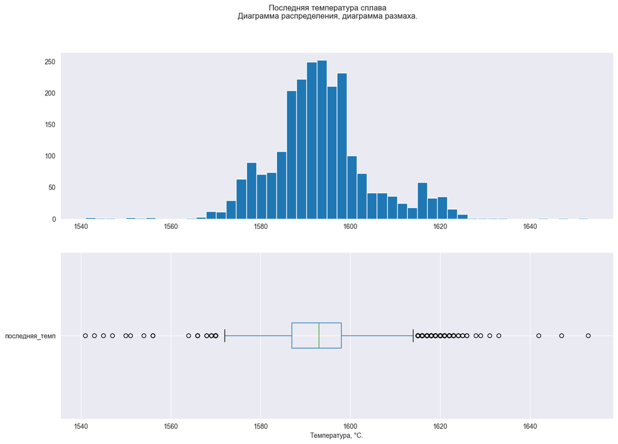

```
count    2329.000000
mean     1593.365393
std        11.200915
min      1541.000000
25%      1587.000000
50%      1593.000000
75%      1598.000000
max      1653.000000
Name: последняя_темп, dtype: float64
```

```python
# исследуем последнюю температуру сплавов
plot_hist_boxplot(df=df_merged,
                  column='последняя_темп',
                  title='Последняя температура сплава\n\
Диаграмма распределения, диаграмма размаха.',
                  xlabel='Температура, °C.',
                  bins=[50])
```

**Итог:**

### Объёмы подачи проволоки

**Исследуем объёмы подачи проволоки в сплавы: `проволока_...`.**

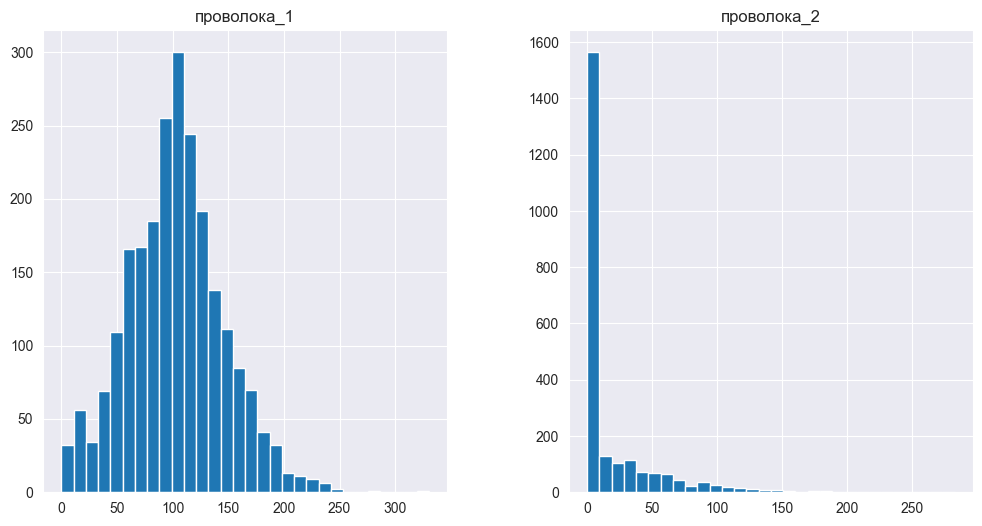

```python
# строим гистограммы
filter_col = [col for col in df_merged if col.startswith('проволока')]
df_merged[filter_col].hist(figsize=(12, 6), bins=30)
plt.show()
```

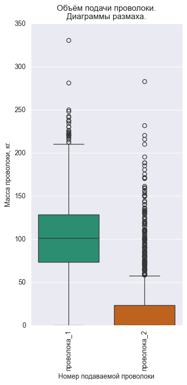

```python
# построим диаграммы размаха
ax = plt.subplots(figsize = (4,8))
ax = sns.boxplot(x="variable", y="value",
                 data=pd.melt(df_merged[filter_col]), palette=palette)
ax.set_title('Объём подачи проволоки.\nДиаграммы размаха.')
ax.set_ylabel('Масса проволоки, кг.')
ax.set_xlabel('Номер подаваемой проволоки')
ax.set_xticklabels(ax.get_xticklabels(),rotation=90)
sns.set_style('darkgrid')

plt.ylim(0, 350)
plt.show()
```

```python
# выведем основные описательные статистики
df_merged[filter_col].describe()
```

|  | проволока_1 | проволока_2 |
| --- | --- | --- |
| count | 2329.000000 | 2329.000000 |
| mean | 102.443601 | 17.609859 |
| std | 43.539993 | 33.624771 |
| min | 0.000000 | 0.000000 |
| 25% | 73.207679 | 0.000000 |
| 50% | 101.119201 | 0.000000 |
| 75% | 128.091599 | 23.102560 |
| max | 330.314424 | 282.780152 |

**Итог:**

- Гистограмма и диаграмма размаха подачи проволоки №2 выглядят неестественно, поскольку некоторые виды проволоки подавались редко и большинство данных представлено нулями.
- В данных имеются существенные выбросы, что обусловлено большим числом нулей.

### Длительность нагрева

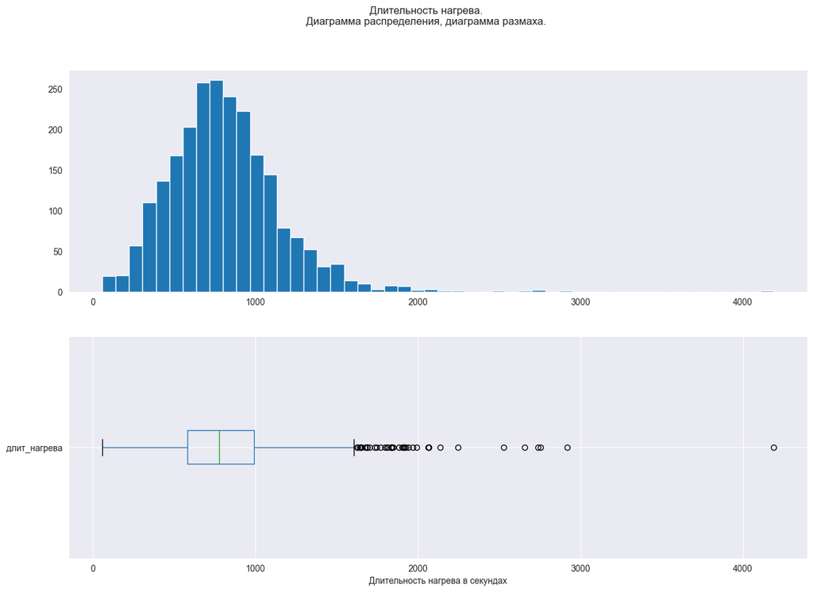

```
count    2329.000000
mean      807.600687
std       340.897332
min        57.000000
25%       581.000000
50%       778.000000
75%       993.000000
max      4189.000000
Name: длит_нагрева, dtype: float64
```

```python
# исследуем данные длительности нагрева
plot_hist_boxplot(df=df_merged,
                  column='длит_нагрева',
                  title='Длительность нагрева.\n\
Диаграмма распределения, диаграмма размаха.',
                  xlabel='Длительность нагрева в секундах',
                  bins=[50])
```

**Итог:**

- Гистограмма близка к нормальной.
- На диаграмме размаха видны выбросы. В случае недостаточной прогнозной точности моделей удалим выбросы из обучающей выборки.
- Данные выглядят корректно.

### Работа

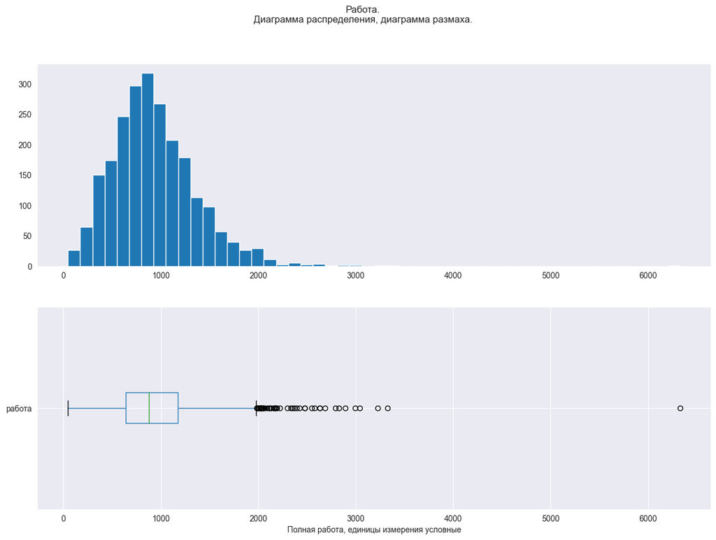

```
count    2329.000000
mean      935.346198
std       446.293807
min        46.967133
25%       637.080260
50%       879.245492
75%      1172.887154
max      6330.135700
Name: работа, dtype: float64
```

```python
# исследуем данные длительности нагрева
plot_hist_boxplot(df=df_merged,
                  column='работа',
                  title='Работа.\n\
Диаграмма распределения, диаграмма размаха.',
                  xlabel='Полная работа, единицы измерения условные',
                  bins=[50])
```

**Итог:**

- Гистограмма близка к нормальной.
- На диаграмме размаха видны выбросы. В случае недостаточной прогнозной точности моделей удалим выбросы из обучающей выборки.
- Данные выглядят корректно.

### Корреляционный анализ

Построим матрицу корреляции признаков с помощью библиотеки `phik`.

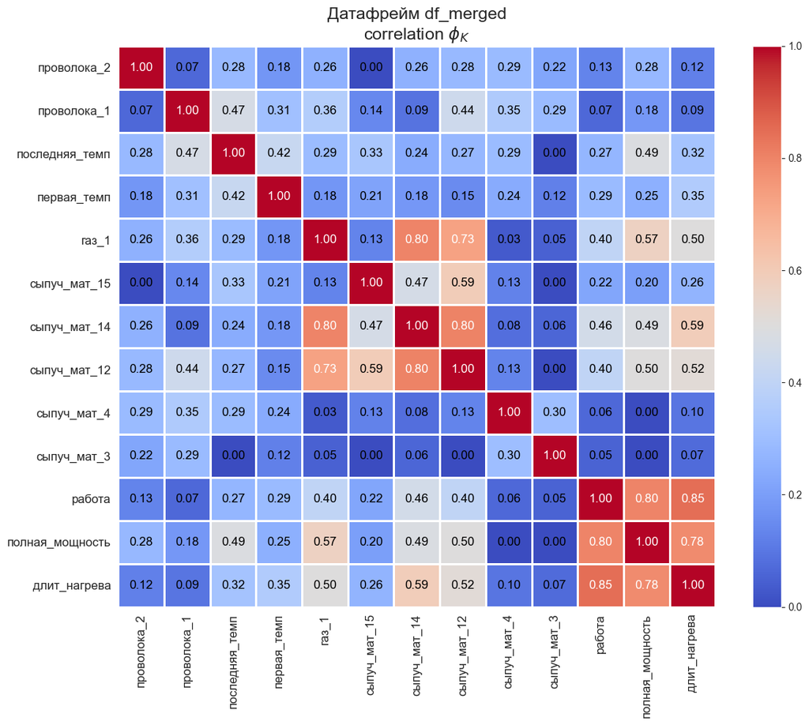

```python
# считаем корреляции df
phik_overview = phik_matrix(df=df_merged, interval_cols=df_merged.columns)

# строим матрицу
plot_correlation_matrix(
    phik_overview.values,
    x_labels=phik_overview.columns,
    y_labels=phik_overview.index,
    vmin=0, vmax=1, color_map='coolwarm',
    title=f'Датафрейм df_merged\ncorrelation $\phi_K$',
    fontsize_factor=1.2,
    figsize=(12, 10))
plt.show()
```

Корреляции не превышают 0,85. Это означает низкий риск мультиколлинеарности.

**Вывод:**

- Данные объединенного датафрейма `df_merged` исследованы и выглядят корректно.

## Подготовка данных и обучение моделей

Выполним подготовку данных для обучения модели. Разделим данные на две выборки, при масштабировании и кодировании учитём особенности данных и моделей.

Обучим три модели:

1. Модель линейной регрессии **LinearRegression**;
2. Модель градиентного бустинга **LightGBM**;
3. Модель дерева решений **DecisionTree**.
- Целевой признак: `последняя_темп`.
- Разобьём данные на обучающую и тестовую выборки в соотношении 75:25.
- Для выбора лучшей модели будем считать метрику MAE. Значение метрики MAE должно не больше 6,8.

```python
## делим данные на тренировочные и тестовые----------------------------------
X = df_merged.drop('последняя_темп', axis=1) # входные признаки
y = df_merged['последняя_темп']              # целевой признак

# разделим данные на тренировочные и тестовые, зафиксируем random_state
X_train, X_test, y_train, y_test = train_test_split(
    X,
    y,
    random_state=RANDOM_STATE,
    test_size=TEST_SIZE)

X_train.shape, X_test.shape, y_train.shape, y_test.shape
```

```
((1746, 12), (583, 12), (1746,), (583,))
```

```python
# количественные признаки - это все столбцы тренировочной выборки
num_columns = list(X_train.columns)

# выведем наименования столбцов
num_columns
```

```
['длит_нагрева',
 'полная_мощность',
 'работа',
 'сыпуч_мат_3',
 'сыпуч_мат_4',
 'сыпуч_мат_12',
 'сыпуч_мат_14',
 'сыпуч_мат_15',
 'газ_1',
 'первая_темп',
 'проволока_1',
 'проволока_2']
```

```python
# создаём пайплайн для подготовки данных
data_preprocessor = ColumnTransformer(
    [
        ('num', StandardScaler(), num_columns) # масштабируем количественные признаки
    ],
    remainder='passthrough'
)

# создаём итоговый пайплайн: подготовка данных и модель
pipe_final = Pipeline([
    ('preprocessor', data_preprocessor),
    ('models', LinearRegression())
])
```

```python
# перебираем гиперпараметры моделей
param_grid = [


    # словарь для модели LinearRegression()
    {
        'models': [LinearRegression()],
        'preprocessor__num': [StandardScaler(), MinMaxScaler(), 'passthrough']

    },


   # словарь для модели DecisionTreeRegressor()
    {
        'models': [DecisionTreeRegressor(random_state=RANDOM_STATE)],
        'models__criterion': ['mean_absolute_error'],
        'models__max_depth': range(2, 10),
        'models__max_features': range(2, 10),
        'preprocessor__num': [StandardScaler(), 'passthrough']
    },


     # словарь для модели LGBMRegressor()
    {
        'models': [LGBMRegressor(random_state=RANDOM_STATE)],
        'models__boosting_type': ['gbdt', 'dart'],
        'preprocessor__num': [StandardScaler(), MinMaxScaler(), 'passthrough']
    },

]
```

```python
model = GridSearchCV(
    pipe_final,
    param_grid,
    cv=5,
    scoring='neg_mean_absolute_error',
    verbose=1,
    n_jobs=-1)
```

```python
%%time
# обучаем модели
model.fit(X_train, y_train)
```

```
Fitting 5 folds for each of 137 candidates, totalling 685 fits
CPU times: total: 1.02 s
Wall time: 7.18 s
```

```
GridSearchCV(cv=5,
             estimator=Pipeline(steps=[('preprocessor',
                                        ColumnTransformer(remainder='passthrough',
                                                          transformers=[('num',
                                                                         StandardScaler(),
                                                                         ['длит_нагрева',
                                                                          'полная_мощность',
                                                                          'работа',
                                                                          'сыпуч_мат_3',
                                                                          'сыпуч_мат_4',
                                                                          'сыпуч_мат_12',
                                                                          'сыпуч_мат_14',
                                                                          'сыпуч_мат_15',
                                                                          'газ_1',
                                                                          'первая_темп',
                                                                          'проволока_1',
                                                                          'проволока_2'])])),
                                       ('models', LinearRegression())]),
             n_jobs=...
                          'models__criterion': ['mean_absolute_error'],
                          'models__max_depth': range(2, 10),
                          'models__max_features': range(2, 10),
                          'preprocessor__num': [StandardScaler(),
                                                'passthrough']},
                         {'models': [LGBMRegressor(random_state=80424)],
                          'models__boosting_type': ['gbdt', 'dart'],
                          'preprocessor__num': [StandardScaler(),
                                                MinMaxScaler(),
                                                'passthrough']}],
             scoring='neg_mean_absolute_error', verbose=1)
```

## Анализ моделей

```python
# отображаем всё содержимое ячеек
pd.set_option('display.max_colwidth', None)

# выводим из списка параметры лучшей модели
cv_results =  pd.DataFrame(model.cv_results_).sort_values('rank_test_score', ascending=1)

print('Лучшая модель:')
cv_results[cv_results['rank_test_score']== 1].set_index('param_models').T
```

```
Лучшая модель:
```

| param_models | LinearRegression() | LinearRegression() |
| --- | --- | --- |
| mean_fit_time | 0.011598 | 0.0068 |
| std_fit_time | 0.001358 | 0.0004 |
| mean_score_time | 0.006518 | 0.0034 |
| std_score_time | 0.002107 | 0.00049 |
| param_preprocessor__num | MinMaxScaler() | passthrough |
| param_models__criterion | NaN | NaN |
| param_models__max_depth | NaN | NaN |
| param_models__max_features | NaN | NaN |
| param_models__boosting_type | NaN | NaN |
| params | {'models': LinearRegression(), 'preprocessor__num': MinMaxScaler()} | {'models': LinearRegression(), 'preprocessor__num': 'passthrough'} |
| split0_test_score | -6.54184 | -6.54184 |
| split1_test_score | -6.558325 | -6.558325 |
| split2_test_score | -6.370568 | -6.370568 |
| split3_test_score | -6.656749 | -6.656749 |
| split4_test_score | -6.599094 | -6.599094 |
| mean_test_score | -6.545315 | -6.545315 |
| std_test_score | 0.095945 | 0.095945 |
| rank_test_score | 1 | 1 |

```python
print('Метрика MAE лучшей модели на кросс-валидации:',
      round(abs(model.best_score_),2))

y_pred = model.predict(X_test)
mae = round(mean_absolute_error(y_test, y_pred),2)
print('Метрика MAE лучшей модели на тестовой выборке:', mae)

r2 = round(r2_score(y_test, y_pred),2)
print('Метрика R2 лучшей модели на тестовой выборке:', r2)
```

```
Метрика MAE лучшей модели на кросс-валидации: 6.55
Метрика MAE лучшей модели на тестовой выборке: 6.4
Метрика R2 лучшей модели на тестовой выборке: 0.33
```

Проверим нашу модель на адекватность, сравнив результат с предсказанием модели `DummyRegressor`.

```python
# инициализируем модель DummyRegressor, обучим и получим прогноз
dummy_сlass = DummyRegressor(strategy="mean")
dummy_сlass.fit(X_train, y_train)
dummy_preds = dummy_сlass.predict(X_test)

dummy_mae = round(mean_absolute_error(y_test, dummy_preds),2)

print(f'Метрика MAE DummyRegressor на тестовой выборке : {dummy_mae}')
```

```
Метрика MAE DummyRegressor на тестовой выборке : 7.88
```

Лучшая модель покузывает более низкую среднюю абсолютную ошибку, чем `DummyRegressor` при стратегии `"mean"`. Проверка на адекватность пройдена.

**Вывод:**

- Лучшая модель получена при помощи линейной регрессии:

- Метрика MAE лучшей модели на тестовой выборке: 6.4, что удовоетворяет требованиям заказчика (не более 6.8).
- Метрика R2 лучшей модели на тестовой выборке: 0.33, что в общем случае является низуим показателем, но при его оценке следует учитывать специфику задачи. Как показал исследовательский анализ, многие материалы подавались в сплав редко (в не более 20% партий) и таких материалов 17 наименований. Гистограммы добавления остальных материалов тоже далеки от нормального распределения. Можно предположить, что модель недообучена и при увеличении выборки данных можно добиться более точных прогнозов.
- Лучшая модель покузывает более низкую среднюю абсолютную ошибку, чем константная модель `DummyRegressor` при стратегии `"mean"`. Проверка на адекватность пройдена, это значит что модель может быть полезна для бизнеса.

## Анализ важности признаков.

Оценим важность признаков для лучшей модели и построим график важности с помощью метода SHAP.

```python
# делаем обработку данных train
x_Train = pipe_final.named_steps['preprocessor'].fit_transform(X_train)

# задаем объект shap.Explainer()
explainer = shap.Explainer(model.best_estimator_.named_steps['models'], x_Train)

# делаем обработку данных test
x_Test = pipe_final.named_steps['preprocessor'].transform(X_test)

feature_names = pipe_final.named_steps['preprocessor'].get_feature_names_out(input_features=None)

x_Test = pd.DataFrame(x_Test, columns=feature_names)

# объясняем переменные
shap_values = explainer(x_Test)
```

**График влияния каждого признака на предсказание модели**

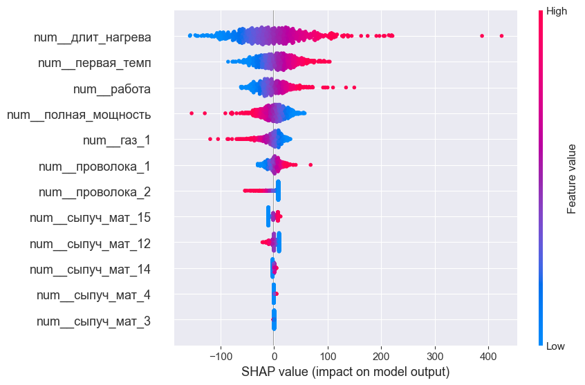

```python
shap.plots.beeswarm(shap_values, max_display=20)
```

```python
# выведем самые важные входные признаки первых пяти предсказаний
X_test[['первая_темп', 'длит_нагрева', 'полная_мощность', 'работа']].head()
```

| партия | первая_темп | длит_нагрева | полная_мощность | работа |
| --- | --- | --- | --- | --- |
| 1270 | 1606.0 | 588 | 3.417810 | 714.861868 |
| 207 | 1580.0 | 480 | 4.979621 | 457.382084 |
| 2276 | 1566.0 | 689 | 4.250777 | 756.849181 |
| 1721 | 1615.0 | 912 | 6.612464 | 911.397868 |
| 2485 | 1582.0 | 1125 | 5.896184 | 1119.592780 |

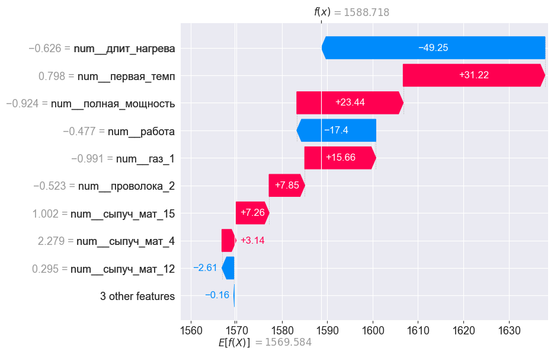

```python
# рассмотрим влияние признаков на первое предсказание.
shap.plots.waterfall(shap_values[0])
```

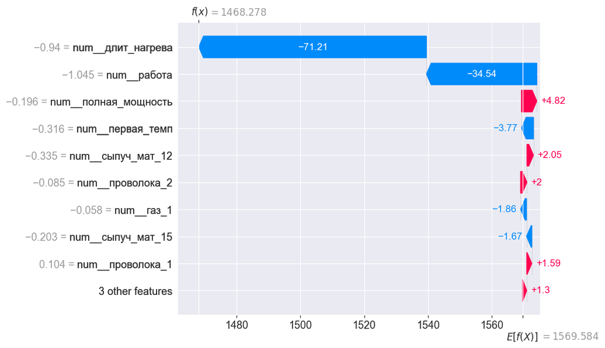

```python
# рассмотрим влияние признаков на второе предсказание.
shap.plots.waterfall(shap_values[1])
```

**Вывод:**

Конечная температура прямо пропорциональна первой температуре, длительности нагрева и работе. При этом конечная температура сплава обратно пропорциональна полной мощности, что выглядит неестественно.

На графике отчетливо видно более высокое влиние добавления проволоки №1 по сравнению с другими материалами. Это обусловлено самым низким количеством пропусков в данных, т.е. данных было достаточно, чтобы модель смогла на них как следует обучиться. Следовательно, для повышения точности предсказаний необходимо расширить выборку и обучить модель на большем количестве данных, тогда и остальные признаки смогут внести свой вклад.

## Общий вывод

**Цель проекта:**

- построить модель, которая будет предсказывать конечную температуру сплава (задача регрессии).

**В ходе проекта мы провели следующую работу:**

- изучили данные, проверили их на предмет аномалий и несоответствий;
- произвели предобработку для последующего анализа: проверили данные на пропуски и дубликаты, исправили ошибки;
- произвели исследовательский анализ данных заказчика (7 таблиц);
- объединили данные из разных таблиц в единую;
- отобрали нужные признаки и сгенерировали новые;
- произвели корреляционный анализ и установили взаимосвязь между признаками;
- подготовили данные и обучили 3 модели, используя кроссвалидацию и перебор гиперпараметров с помощью GridSearchCV:
  - модель линейной регрессии **LinearRegression**;
  - модель градиентного бустинга **LightGBM**;
  - модель дерева решений **DecisionTree**.
- произвели анализ результатов работы моделей на кроссвалидации и выбрали лучшую по метрике MAE;
- рассчитали метрики MAE и R2 на тестовой выборке.
- произвели оценку адекватности результатов работы лучшей модели с помощью константной модели DummyRegressor;
- произвели анализ важности признаков при помощи модуля Shap.

**Результаты:**

**Рекомендации:**

- Для повышения точности предсказаний необходимо расширить выборку и обучить модель на большем количестве данных.
- В пояснениях к исходным таблицам необходимо указать единицы измерения показателей.